# Eksamensprojekt_DM

Rasmus Henriksen

2023-11-01

#### 0.1 Indlæssing af nødvendig pakke

```r
library(tidyverse)
library(forcats)
```

### 1.0 Indlæssing af data

```r
DE <- read.csv("Data/Danish elections from 1924-1953 - Ark1.csv")
```

### 1.1 “Clean” datasættet for N/A

Med andre ord, gør det brugbart til at skabe nødvendige grafer, selvom der er manglende værdier

```r
DE_clean <- na.omit(DE)
```

## 2.0 Statistik over alle opstillede partier i perioden

```
## `geom_line()`: Each group consists of only one observation.
## ℹ Do you need to adjust the group aesthetic?
```

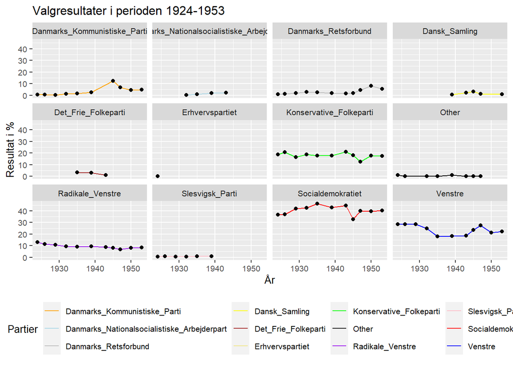

```r
DE_clean %>%
  ggplot(aes(y = Turnout_Percentage, x = Election_Year))+
  geom_line(aes(color = Political_Parties))+
  geom_point()+
  labs(title = "Valgresultater i perioden 1924-1953",
       color = "Partier",
       x = "År",
       y = "Resultat i %") +
  facet_wrap(facets = "Political_Parties",
             ncol = 4,
             nrow = 4) +
  theme(legend.position = "bottom") +
  theme(text = element_text(size = 10)) +
  scale_colour_manual(values = c("Venstre" = "blue", "Socialdemokratiet" = "red", "Radikale_Venstre" = "purple", "Konservative_Folkeparti" = "green", "Danmarks_Kommunistiske_Parti" = "orange", "Danmarks_Retsforbund" = "grey", "Det_Frie_Folkeparti" = "brown", "Slesvigsk_Parti" = "pink", "Dansk_Samling" = "yellow", "Erhvervspartiet" = "khaki", "Danmarks_Nationalsocialistiske_Arbejderpart" = "lightblue", "Other" = "black"))
```

```r
ggsave("Figur1.png")
```

```
## `geom_line()`: Each group consists of only one observation.
## ℹ Do you need to adjust the group aesthetic?
```

Som det kan ses, var der 12 opstillede partier i perioden fra 1924 til 1953. Jeg har valgt at isolere de enkelte partier for at give et bedre overblik. Desuden har jeg tildelt dem partifarver, hvor det var muligt. Link: https://ggplot2.tidyverse.org/reference/scale_manual.html Hvor koden til faverne er fundet

```r
kort_DE <- DE_clean
```

### 3.1 Forkortelser for partierne

```r
kort_DE$Political_Parties <- fct_recode(kort_DE$Political_Parties, "S" = "Socialdemokratiet", "RV" = "Radikale_Venstre", "KF" = "Konservative_Folkeparti", "DR" = "Danmarks_Retsforbund", "DKP" = "Danmarks_Kommunistiske_Parti", "FF" = "Det_Frie_Folkeparti", "SP" = "Slesvigsk_Parti", "V" = "Venstre", "DS" = "Dansk_Samling", "E" = "Erhvervspartiet", "DNSAP" = "Danmarks_Nationalsocialistiske_Arbejderpart")
```

Alle partierne har fået deres forkortelse, da nogle partier havde lange partinavne.

## 3.0 Graf over antallet af opstillede gange i perioden 1924-1953

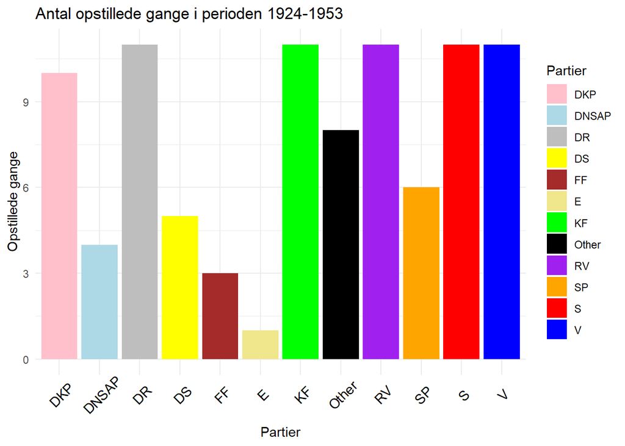

```r
kort_DE %>%
  ggplot(aes(x = Political_Parties)) +
  geom_bar(aes(fill = Political_Parties)) +
  theme_minimal() +
  labs(title = "Antal opstillede gange i perioden 1924-1953",
       fill = "Partier",
       x = "Partier",
       y = "Opstillede gange") +
  theme(axis.text.x = element_text(colour = "black", size = 11, angle = 45,
                                     hjust = 0.5, vjust = 0.7)) +
  scale_fill_manual(values = c("V" = "blue", "S" = "red", "RV" = "purple", "KF" = "green", "DKP" = "pink", "DR" = "grey", "FF" = "brown", "SP" = "orange", "DS" = "yellow", "E" = "khaki", "DNSAP" = "lightblue", "Other" = "black"))
```

```r
ggsave("Figur2.png")
```

Statistik over, hvor mange gange partierne er blevet opstillet i perioden 1924-1953. Partierne har stadig fået deres partifarve, hvis det har været muligt. Der ses en betydelig variation i antallet af opstillinger for partierne i perioden fra 1924 til 1953.

### 4.1 De fire største partier

```r
fire_store <- DE_clean %>%
  filter(Political_Parties == "Socialdemokratiet" | Political_Parties == "Venstre" | Political_Parties == "Radikale_Venstre" | Political_Parties == "Konservative_Folkeparti")
```

## 4.0 Graf over de fire største partier i perioden

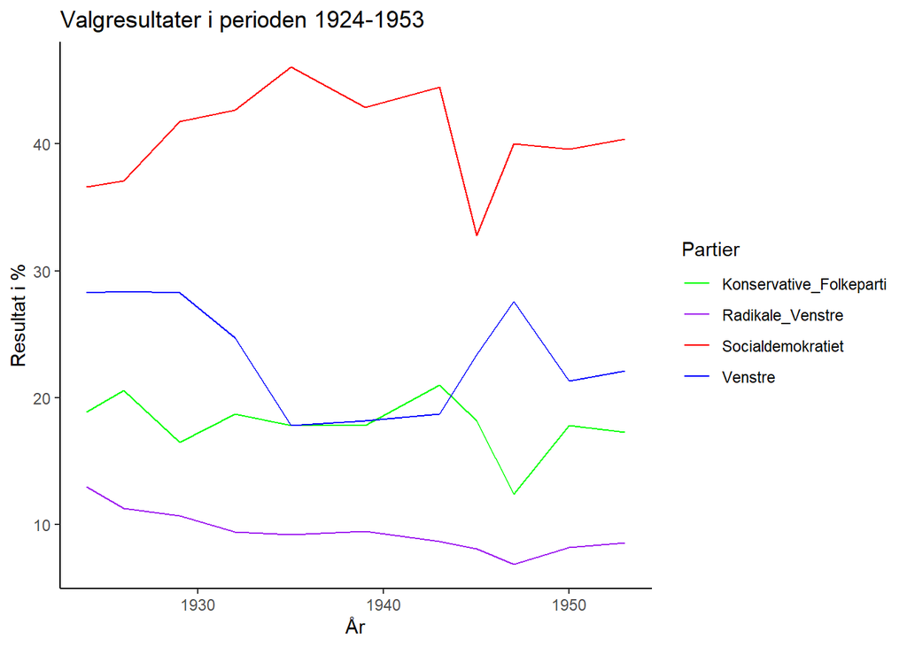

```r
ggplot(data = fire_store)+
  geom_line(aes(x = Election_Year, y = Turnout_Percentage , color = Political_Parties)) +
  theme_classic() +
  labs(title = "Valgresultater i perioden 1924-1953",
       color = "Partier",
       x = "År",
       y = "Resultat i %") +
  scale_colour_manual(values = c("Venstre" = "blue", "Socialdemokratiet" = "red", "Radikale_Venstre" = "purple", "Konservative_Folkeparti" = "green"))
```

```r
ggsave("Figur3.png")
```

De fire største partier er blevet isoleret for at give et bedre overblik over de største stemmemagneter.

## 5.0 Tendenser over de fire største partier

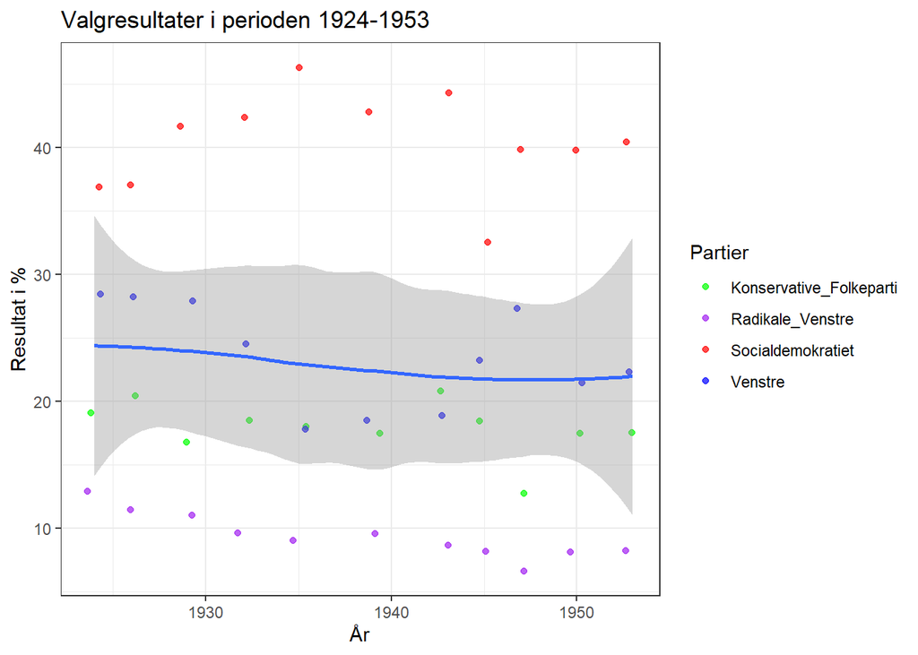

```r
ggplot(data = fire_store) +
    geom_jitter(aes(x = Election_Year, y = Turnout_Percentage, color = Political_Parties), alpha = 0.7, width = 0.4, height = 0.4) +
  geom_smooth(aes(x = Election_Year, y = Turnout_Percentage)) +
  theme_bw() +
  labs(title = "Valgresultater i perioden 1924-1953",
       color = "Partier",
       x = "År",
       y = "Resultat i %") +
  scale_colour_manual(values = c("Venstre" = "blue", "Socialdemokratiet" = "red", "Radikale_Venstre" = "purple", "Konservative_Folkeparti" = "green"))
```

```r
ggsave("Figur4.png")
```

Her ses, hvordan de samlede resultater har udviklet sig for de fire største partier i perioden. Deres resultater er vist som punkter for at give en alternativ visualisering.

### 6.1 Valgresultaterne i krigsårene er isoleret

```r
Krigs_år <- DE_clean %>%
  filter(Election_Year == "1939" | Election_Year == "1943" | Election_Year == "1945" | Election_Year == "1947" | Election_Year == "1950")
```

### 6.0 Graf over valgresultaterne i de omkringliggende krigsår.

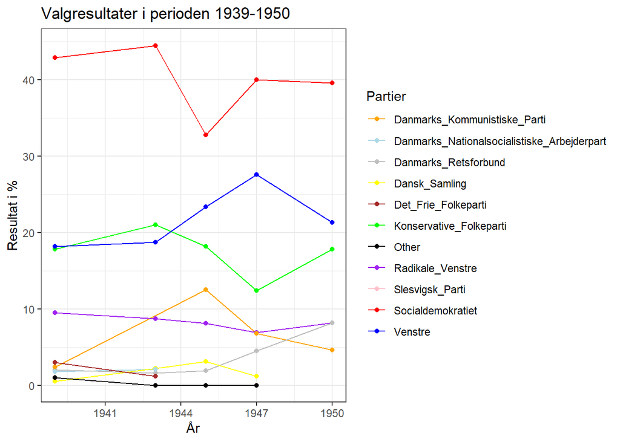

```r
ggplot(data = Krigs_år)+
  (aes(x = Election_Year, y = Turnout_Percentage , color = Political_Parties)) +
  labs(title = "Valgresultater i perioden 1939-1950",
       color = "Partier",
       x = "År",
       y = "Resultat i %") +
  geom_line() +
  geom_point() +
  theme_bw() +
  scale_colour_manual(values = c("Venstre" = "blue", "Socialdemokratiet" = "red", "Radikale_Venstre" = "purple", "Konservative_Folkeparti" = "green", "Danmarks_Kommunistiske_Parti" = "orange", "Danmarks_Retsforbund" = "grey", "Det_Frie_Folkeparti" = "brown", "Slesvigsk_Parti" = "pink", "Dansk_Samling" = "yellow", "Danmarks_Nationalsocialistiske_Arbejderpart" = "lightblue", "Other" = "black"))
```

```r
ggsave("Figur5.png")
```

Årene omkring 2. verdenskrig er blevet isoleret og vist på en graf. Dette skyldes, at det kan være særligt relevant for denne periode.